# Experiment 1

```r
##change reference level to get the remaining comparisons

lm_final_relevel = lmer(value~relevel(as.factor(Type), ref = "Gender")*Statement+(0+Statement|Concept)+(0+Type+Statement|index), control = lmerControl(optimizer ='optimx', optCtrl=list(method='nlminb')), dt_c)
summary(lm_final_relevel)
```

```
## Linear mixed model fit by REML. t-tests use Satterthwaite's method [
## lmerModLmerTest]
## Formula: value ~ relevel(as.factor(Type), ref = "Gender") * Statement +
##     (0 + Statement | Concept) + (0 + Type + Statement | index)
##    Data: dt_c
## Control:
## lmerControl(optimizer = "optimx", optCtrl = list(method = "nlminb"))
##
## REML criterion at convergence: 45855.9
##
## Scaled residuals:
##     Min      1Q  Median      3Q     Max
## -4.4112 -0.4552  0.0440  0.4751  4.2073
##
## Random effects:
##  Groups   Name              Variance Std.Dev. Corr
##  index    TypeControl       0.3430   0.5856
##           TypeDualCharacter 0.6667   0.8165    0.83
##           TypeGender        0.7782   0.8821    0.77  0.94
##           StatementTrue     1.6355   1.2789   -0.39 -0.61 -0.49
##  Concept  StatementGood     0.4538   0.6736
##           StatementTrue     0.4607   0.6788   -0.36
##  Residual                   1.5574   1.2480
## Number of obs: 13524, groups:  index, 161; Concept, 42
##
## Fixed effects:
##                                                                     Estimate
## (Intercept)                                                           6.4907
## relevel(as.factor(Type), ref = "Gender")Control                      -0.3099
## relevel(as.factor(Type), ref = "Gender")DualCharacter                -0.2957
## StatementTrue                                                        -1.8043
## relevel(as.factor(Type), ref = "Gender")Control:StatementTrue        -1.0351
## relevel(as.factor(Type), ref = "Gender")DualCharacter:StatementTrue   0.6463
##                                                                     Std. Error
## (Intercept)                                                             0.4864
## relevel(as.factor(Type), ref = "Gender")Control                         0.5069
## relevel(as.factor(Type), ref = "Gender")DualCharacter                   0.5054
## StatementTrue                                                           0.8015
## relevel(as.factor(Type), ref = "Gender")Control:StatementTrue           0.8339
## relevel(as.factor(Type), ref = "Gender")DualCharacter:StatementTrue     0.8339
```

[output cut: 29 more lines]

```
## Signif. codes:  0 '***' 0.001 '**' 0.01 '*' 0.05 '.' 0.1 ' ' 1
##
## Correlation of Fixed Effects:
##                  (Intr) rl(.(T),r="G")C rl(.(T),r="G")DC SttmnT
## rl(.(T),r="G")C  -0.950
## rl(.(T),r="G")DC -0.945  0.907
## StatementTr      -0.815  0.778           0.775
## r(.(T),r="G")C:   0.775 -0.818          -0.746           -0.946
## r(.(T),r="G")DC:  0.775 -0.744          -0.820           -0.946
##                  r(.(T),r="G")C:
## rl(.(T),r="G")C
## rl(.(T),r="G")DC
## StatementTr
## r(.(T),r="G")C:
## r(.(T),r="G")DC:  0.909
```

```r
anova(lm_final_relevel)
```

```
## Type III Analysis of Variance Table with Satterthwaite's method
##                                                    Sum Sq Mean Sq NumDF
## relevel(as.factor(Type), ref = "Gender")           71.931  35.965     2
## Statement                                          61.674  61.674     1
## relevel(as.factor(Type), ref = "Gender"):Statement 34.911  17.456     2
##                                                     DenDF F value
## relevel(as.factor(Type), ref = "Gender")           42.679  23.093
## Statement                                          48.780  39.601
## relevel(as.factor(Type), ref = "Gender"):Statement 39.001  11.208
##                                                       Pr(>F)
## relevel(as.factor(Type), ref = "Gender")           1.596e-07 ***
## Statement                                          8.404e-08 ***
## relevel(as.factor(Type), ref = "Gender"):Statement 0.0001426 ***
## ---
## Signif. codes:  0 '***' 0.001 '**' 0.01 '*' 0.05 '.' 0.1 ' ' 1
```

####Bar Graph for Statements and Concepts (error bars represent 95% confidence intervals)

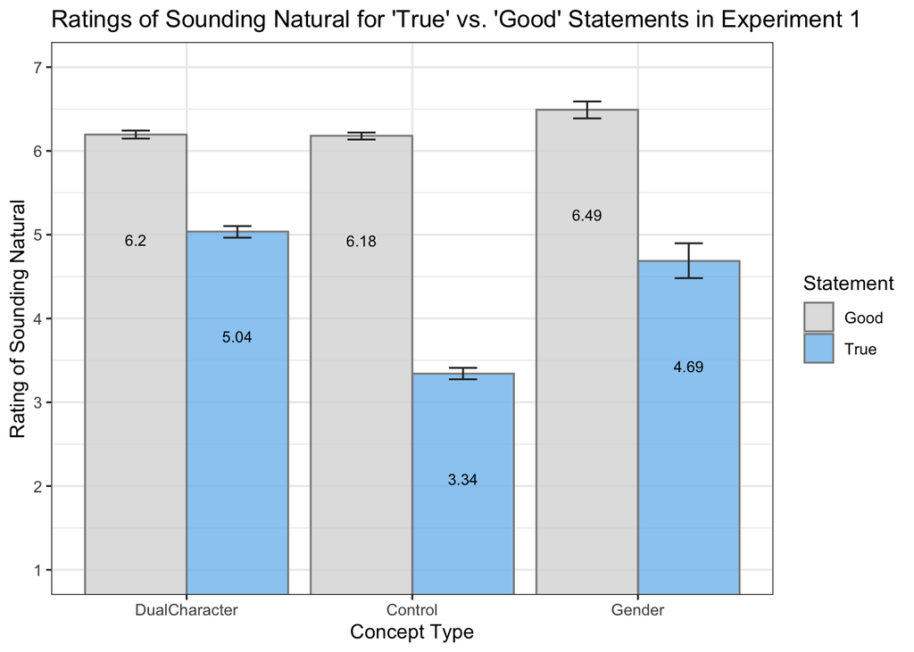

```r
full_graph <- dt_c %>%
  group_by(Type, Statement) %>%
  summarise(Mean = mean(value,na.rm=T),
            upper = Mean + ci.high(value),
            lower = Mean - ci.low(value))

full_graph$Type = factor(full_graph$Type,levels = c("DualCharacter", "Control", "Gender"))

ggplot(full_graph,aes(x=Type, y=Mean, fill=Statement, label = round(Mean, digits=2))) +
  geom_bar(position="dodge", stat="identity", col = "snow4") + scale_fill_manual(values=alpha(c("grey85", "skyblue2"), .8)) +
  geom_errorbar(   aes( ymax=upper, ymin=lower ) ,
                            width   =.25,
                            linetype="solid", col = "gray19", position=position_dodge(.9)
                            ) +
  theme_bw() + ggtitle("Ratings of Sounding Natural for 'True' vs. 'Good' Statements in Experiment 1") + geom_text(size = 3, position = position_dodge(width=.9), col = "black", vjust=10) + labs(x = "Concept Type", y = "Rating of Sounding Natural") + coord_cartesian(ylim=c(1,7)) + scale_y_continuous(breaks = c(1:7))
```

```r
#get descriptives (e.g. means and SDs)
print(full_graph)
```

```
## # A tibble: 6 x 5
## # Groups:   Type [3]
##   Type          Statement  Mean upper lower
##   <fct>         <fct>     <dbl> <dbl> <dbl>
## 1 Control       Good       6.18  6.22  6.14
## 2 Control       True       3.34  3.41  3.27
## 3 DualCharacter Good       6.20  6.24  6.15
## 4 DualCharacter True       5.04  5.10  4.96
## 5 Gender        Good       6.49  6.59  6.39
## 6 Gender        True       4.69  4.90  4.48
```

####Rank Order Graph for True Statements

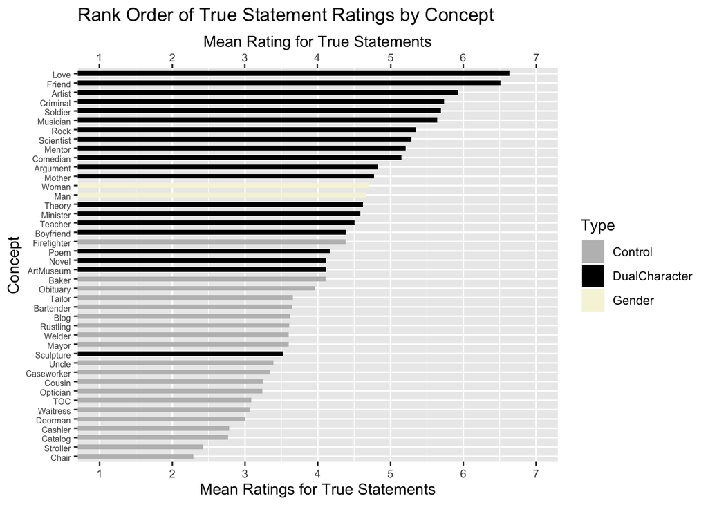

```r
d_true = dt_c %>%
  filter(Statement=="True") %>%
  spread(Statement, value)

rank_order <- d_true %>%
  group_by(Concept, Type) %>%
  summarise(Mean = mean(True,na.rm=T))

ggplot(rank_order, aes(x=reorder(Concept, Mean), y=Mean, fill = Type, label = round(Mean, digits=2))) + geom_bar(width = .5, stat="identity",position = position_dodge(width = .5)) + ggtitle("Rank Order of True Statement Ratings by Concept") + scale_x_discrete(name = "Concept") + scale_fill_manual(values = c("grey", "black", "beige")) +  scale_y_continuous(name="Mean Ratings for True Statements", breaks = c(1:7), sec.axis = sec_axis(~.*1, name = "Mean Rating for True Statements", breaks = c(1:7)))+ coord_flip(ylim=c(1,7)) + theme (axis.text.x = element_text(vjust=0.7, size=8, angle=0)) + theme (axis.text.y = element_text(vjust=0.7, size=6, angle=0))
```

## Bayes Factors

```r
#creating new Type variables to prepare for the BayesFactor analyses.
##Type is for the original model A where all types are treated independently
##Type1 is for the model B where Dual-Character and Gender are treated as the same
##Type2 is for the model C where Control and Gender are treated as the same
##Type3 is for the model D where Dual-Character and Control are treated as the same


dt_d = dt_c %>%
  mutate(Type1 = recode(Type, "c('DualCharacter', 'Gender') = 'DG'"), Type2 = recode(Type, "c('Control', 'Gender') = 'CG'"), Type3 = recode(Type, "c('DualCharacter', 'Control') = 'DC'"))

dt_d$value = as.numeric(dt_d$value)

#bfA is the all-different model A where Dual-Character, Control, Man, and Woman are all separate
bfA = lmBF(value~Type+Statement+Type*Statement, data = as.data.frame(dt_d), whichRandom = c("Concept", "index"))
bfA
```

```
## Bayes factor analysis
## --------------
## [1] Type + Statement + Type * Statement : 9.481502e+1124 ±3.27%
##
## Against denominator:
##   Intercept only
## ---
## Bayes factor type: BFlinearModel, JZS
```

```r
#bfB is the model B where gender = dual character but not control

bfB = lmBF(value~Type1+Statement+Type1*Statement, data = as.data.frame(dt_d), whichRandom = c("Concept", "index"))
bfB
```

```
## Bayes factor analysis
## --------------
## [1] Type1 + Statement + Type1 * Statement : 3.788565e+1122 ±1%
##
## Against denominator:
##   Intercept only
## ---
## Bayes factor type: BFlinearModel, JZS
```

```r
#bfC is the model C where gender = control but not dual-character
bfC = lmBF(value~Type2+Statement+Type2*Statement, data = as.data.frame(dt_d), whichRandom = c("Concept", "index"))
bfC
```

```
## Bayes factor analysis
## --------------
## [1] Type2 + Statement + Type2 * Statement : 1.166471e+1085 ±1.01%
##
## Against denominator:
##   Intercept only
## ---
## Bayes factor type: BFlinearModel, JZS
```

```r
#bfD is the model D where dual-character = control but not gender
bfD = lmBF(value~Type3+Statement+Type3*Statement, data = as.data.frame(dt_d), whichRandom = c("Concept", "index"))
bfD
```

```
## Bayes factor analysis
## --------------
## [1] Type3 + Statement + Type3 * Statement : 5.393707e+794 ±2.18%
##
## Against denominator:
##   Intercept only
## ---
## Bayes factor type: BFlinearModel, JZS
```

```r
#organize all the Bayes factors into a single dataframe
bf_tests1 = c(bfA, bfB, bfC, bfD)
bf_tests1
```

```
## Bayes factor analysis
## --------------
## [1] Type + Statement + Type * Statement   : 9.481502e+1124 ±3.27%
## [2] Type1 + Statement + Type1 * Statement : 3.788565e+1122 ±1%
## [3] Type2 + Statement + Type2 * Statement : 1.166471e+1085 ±1.01%
## [4] Type3 + Statement + Type3 * Statement : 5.393707e+794  ±2.18%
##
## Against denominator:
##   Intercept only
## ---
## Bayes factor type: BFlinearModel, JZS
```

```r
#compare model B (gender = dual-character) to the all different model A
bf_tests1[1]/bf_tests1[2]
```

```
## Bayes factor analysis
## --------------
## [1] Type + Statement + Type * Statement : 250.2663 ±3.42%
##
## Against denominator:
##   value ~ Type1 + Statement + Type1 * Statement
## ---
## Bayes factor type: BFlinearModel, JZS
```

```r
#compare model B (gender = dual-character) to model C (gender = control)
bf_tests1[2]/bf_tests1[3]
```

```
## Bayes factor analysis
## --------------
## [1] Type1 + Statement + Type1 * Statement : 3.247887e+37 ±1.42%
##
## Against denominator:
##   value ~ Type2 + Statement + Type2 * Statement
## ---
## Bayes factor type: BFlinearModel, JZS
```

Model B “Gender = Dual Character” outperforms Model C “Gender = Control” by a large margin.

## Bayes Factors when only considering “true” statements

```r
#Examine only for "true" (or "good" -- change true to good in the following code) statements
dt_d1 = dt_d %>%
  filter(Statement == "True")

#bfA1 is the all-different model comparing the concept types only for "true" statement
bfA1 = lmBF(value~Type, data = as.data.frame(dt_d1), whichRandom = c("Concept", "index"))
bfA1
```

```
## Bayes factor analysis
## --------------
## [1] Type : 1.630576e+233 ±0.02%
##
## Against denominator:
##   Intercept only
## ---
## Bayes factor type: BFlinearModel, JZS
```

```r
#bfB1 is the model where gender = dual character but not control, only for "true"" statement

bfB1 = lmBF(value~Type1, data = as.data.frame(dt_d1), whichRandom = c("Concept", "index"))
```

```
## t is large; approximation invoked.
```

```r
bfB1
```

```
## Bayes factor analysis
## --------------
## [1] Type1 : 2.645592e+232 ±0%
##
## Against denominator:
##   Intercept only
## ---
## Bayes factor type: BFlinearModel, JZS
```

```r
#bfC1 is the model where gender = control but not dual-character, only for "true"" statement

bfC1 = lmBF(value~Type2, data = as.data.frame(dt_d1), whichRandom = c("Concept", "index"))
```

```
## t is large; approximation invoked.
```

```r
bfC1
```

```
## Bayes factor analysis
## --------------
## [1] Type2 : 6.824945e+205 ±0%
##
## Against denominator:
##   Intercept only
## ---
## Bayes factor type: BFlinearModel, JZS
```

```r
#bfD1 is the model where dual-character = control but not gender, only for "true"" statement

bfD1 = lmBF(value~Type3, data = as.data.frame(dt_d1), whichRandom = c("Concept", "index"))
bfD1
```

```
## Bayes factor analysis
## --------------
## [1] Type3 : 192.8763 ±0%
##
## Against denominator:
##   Intercept only
## ---
## Bayes factor type: BFlinearModel, JZS
```

```r
bf_tests2=c(bfA1, bfB1, bfC1, bfD1)
bf_tests2
```

```
## Bayes factor analysis
## --------------
## [1] Type  : 1.630576e+233 ±0.02%
## [2] Type1 : 2.645592e+232 ±0%
## [3] Type2 : 6.824945e+205 ±0%
## [4] Type3 : 192.8763      ±0%
##
## Against denominator:
##   Intercept only
## ---
## Bayes factor type: BFlinearModel, JZS
```

```r
#compare Model B1 gender = dual-character to Model A1 all-different model
bf_tests2[1]/bf_tests2[2]
```

```
## Bayes factor analysis
## --------------
## [1] Type : 6.16337 ±0.02%
##
## Against denominator:
##   value ~ Type1
## ---
## Bayes factor type: BFlinearModel, JZS
```

```r
#compare Model B1 gender = dual-character to Model C1 gender = control
bf_tests2[2]/bf_tests2[3]
```

```
## Bayes factor analysis
## --------------
## [1] Type1 : 3.876356e+26 ±0%
##
## Against denominator:
##   value ~ Type2
## ---
## Bayes factor type: BFlinearModel, JZS
```

Note that since Bayesian analyses run estimations each time they are conducted, the Bayes Factors may change each time you run the following script, but the changes should be minor and would not change the general results. We forgot to use the “set.seed” function to “freeze” the estimations when first running and reporting the results, so when you run the codes, you will get numbers slightly different from those reported in the paper and those generated above.